# Fructose-1,6-bisphosphatase isozyme 2

Fold-switch pair **5et5A_3ifaA** — **5et5A** vs **3ifaA**

Homo sapiens

## Figure 1: Phylogenetic tree with per-cluster fold-preference heatmap.

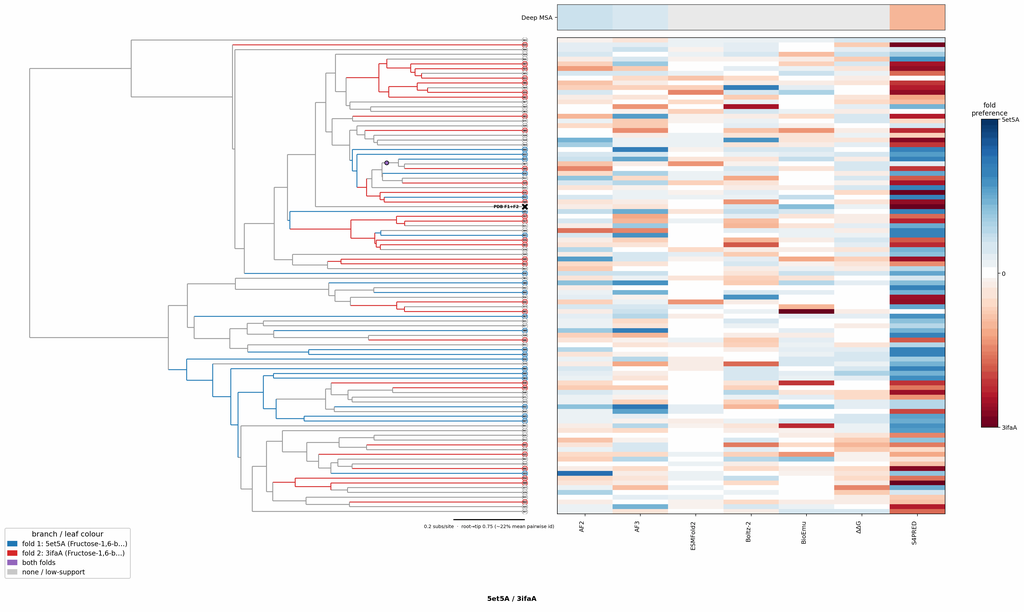

## Figure 2: Aligned overlay (both folds superposed)

The single fold-switching chain of each fold superposed by TM-align; waters hidden, any ligand shown as green sticks. Grey = structurally conserved core, colour = divergent (fold-switching) region.

5et5A (Fructose-1,6-bisphosphatase isozyme 2)3ifaA (Fructose-1,6-bisphosphatase isozyme 2)Ligand AMP (bound to 3ifaA)

TM-score: 0.969 · Trigger class: ligand

Aligned overlay

## Figure 3: The two folds, side by side

Each fold is coloured by per-residue Cα deviation between the two superposed structures: grey ≈ conserved core, full colour = structurally divergent (fold-switching) region.

5et5A (Fructose-1,6-bisphosphatase isozyme 2)

3ifaA (Fructose-1,6-bisphosphatase isozyme 2)

0 Å5≥10 Å

5et5A (Fructose-1,6-bisphosphatase isozyme 2)

3ifaA (Fructose-1,6-bisphosphatase isozyme 2)

## Figure 4: Best-cluster predicted contact maps over the two true folds.

Predicted contact maps (MSA-Transformer) for the clusters best matching each fold, over the true contacts of fold 1 (upper triangle) and fold 2 (lower). Divergent contacts between clusters are the contact-level signature of fold-switching.

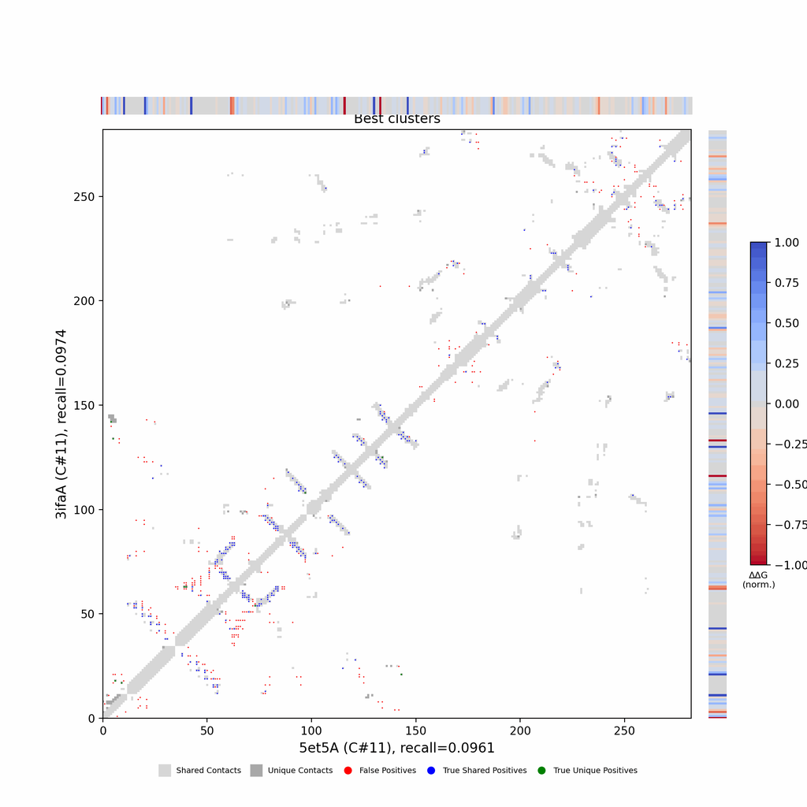

## Figure 5: Per-residue ΔΔG fold-preference contribution

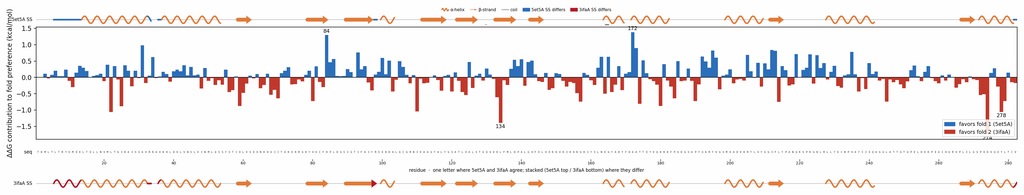

**More figures**

## Figure 6: Deep-MSA contact map panel / Best clusters contact map panel

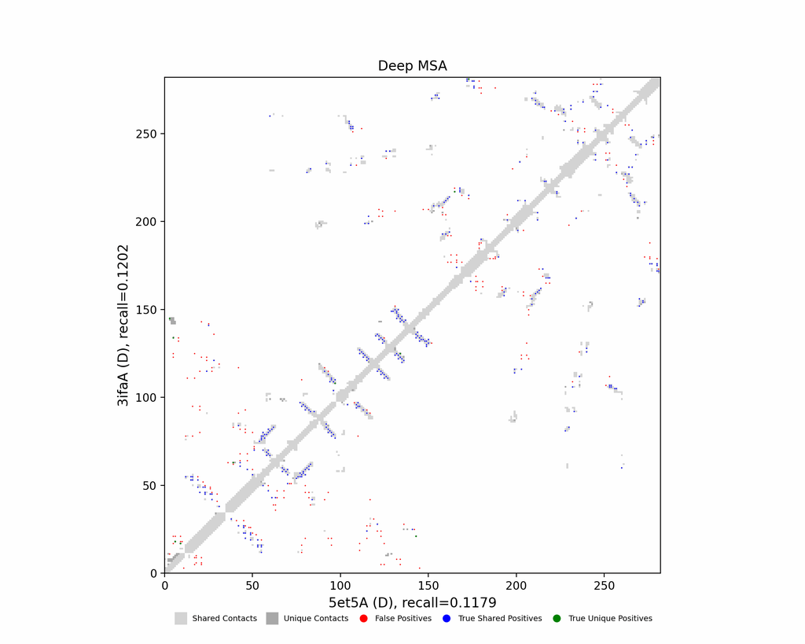

Deep-MSA contact map panel

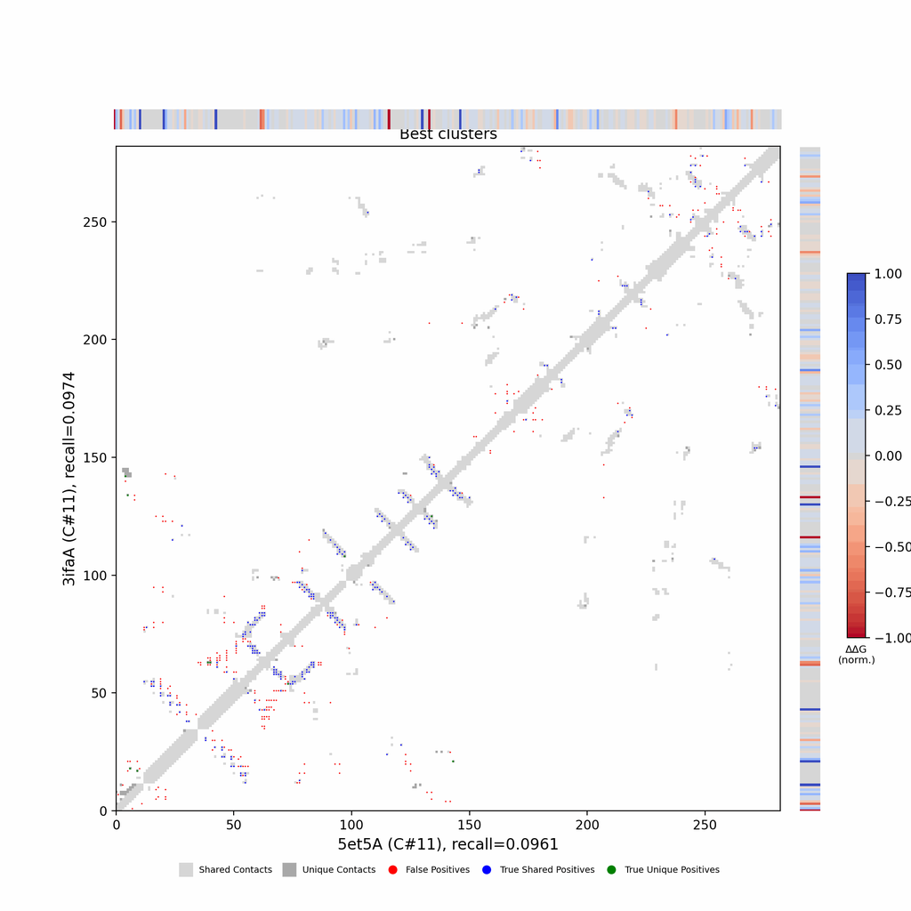

Best clusters contact map panel

## Figure 7: All clusters contact-map mosaic (small multiples).

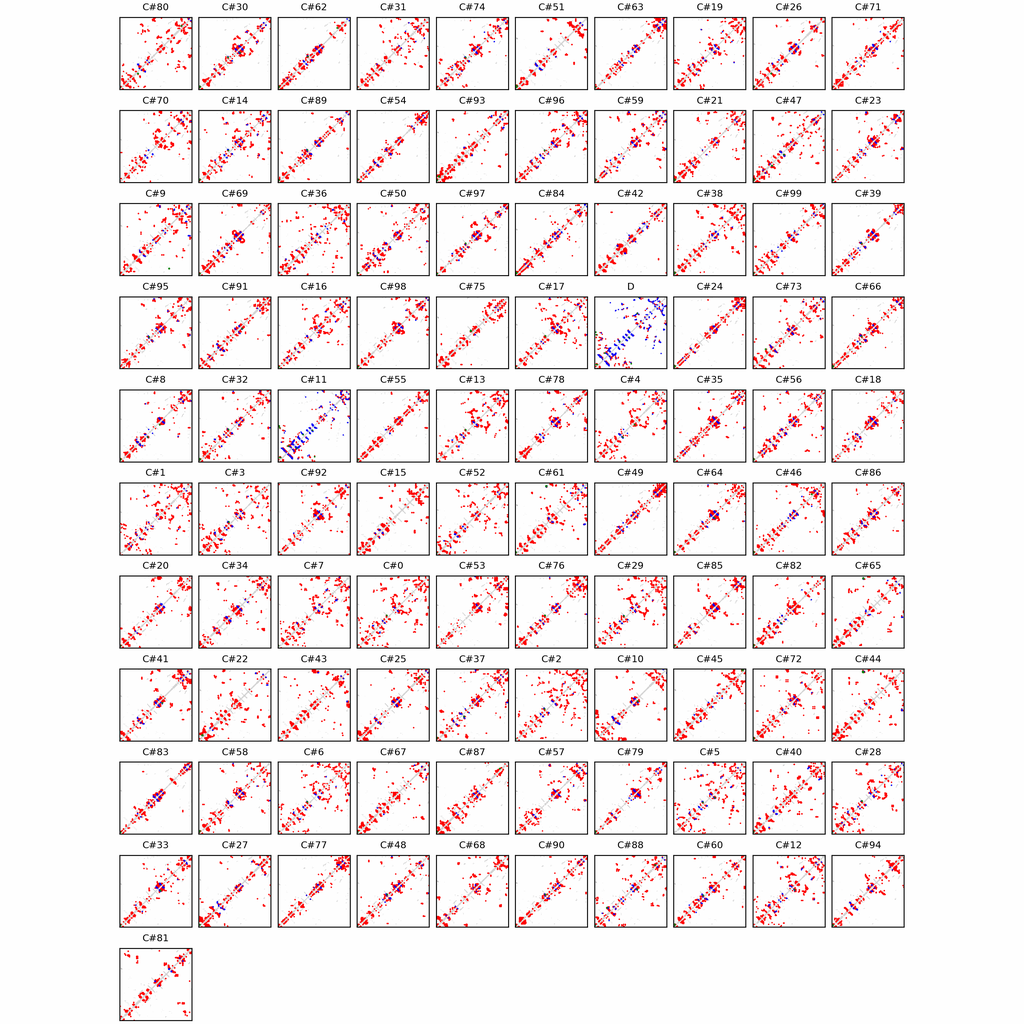

## Figure 8: Phylo null: tree with shuffled cluster fold labels.

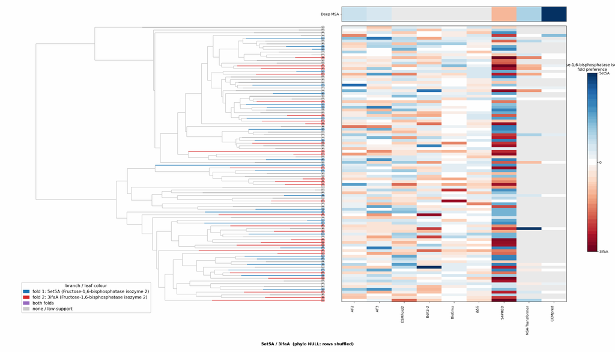

## Cluster metrics table

Per-cluster metrics underlying the figures above.

| cluster | n | neff | AF2_TM1 | AF2_TM2 | AF3_TM1 | AF3_TM2 | RE-MSAT-COM | RE-MSAT1 | RE-MSAT2 | ESM_SEQIDS | ESM_TM1 | ESM_TM2 | ΔΔG_Bias | ΔΔG_Bias_std | ΔΔG_frac_F1 | Boltz2_pref | S4PRED_pref | CCMpred_pref | BioEmu_pref |
| --- | --- | --- | --- | --- | --- | --- | --- | --- | --- | --- | --- | --- | --- | --- | --- | --- | --- | --- | --- |
| Deep | - | - | 0.97 | 0.96 | 0.98 | 0.96 | 0.4 | 0.4 | 0.4 | - | - | - | - | - | - | - | -0.01 | 0.0 | - |
| 000 | 1660.0 | 584.0 | 0.21 | 0.23 | 0.42 | 0.39 | 0.02 | 0.02 | 0.03 | 001; 002; 005; 002; 001; 005; 006; 004; 004; 006 | 0.92 ± 0.01 | 0.87 ± 0.02 | 17.96 | 8.3 | 1.0 | 0.03 | -0.02 | 0.0 | 0.01 |
| 001 | 1216.0 | 412.0 | 0.27 | 0.28 | 0.76 | 0.67 | 0.02 | 0.02 | 0.02 | 001; 001; 003; 003; 005; 005; 004; 004; 009; 009 | 0.88 ± 0.03 | 0.82 ± 0.02 | 16.59 | 6.71 | 1.0 | 0.02 | -0.02 | 0.0 | 0.0 |
| 002 | 943.0 | 445.0 | 0.31 | 0.3 | 0.38 | 0.36 | 0.03 | 0.03 | 0.04 | 001; 001; 002; 002; 003; 003; 004; 004; 007; 007 | 0.87 ± 0.04 | 0.82 ± 0.05 | 16.78 | 9.17 | 1.0 | 0.03 | 0.01 | 0.0 | 0.02 |
| 003 | 789.0 | 255.0 | 0.19 | 0.18 | 0.26 | 0.24 | 0.04 | 0.04 | 0.04 | 001; 001; 004; 004; 006; 006; 005; 005; 003; 003 | 0.81 ± 0.10 | 0.75 ± 0.10 | 16.25 | 7.19 | 1.0 | -0.02 | -0.02 | 0.0 | 0.02 |
| 004 | 678.0 | 278.0 | 0.29 | 0.24 | 0.4 | 0.36 | 0.02 | 0.02 | 0.02 | 004; 004; 003; 003; 005; 006; 006; 005; 001; 001 | 0.92 ± 0.01 | 0.87 ± 0.04 | 15.64 | 7.31 | 1.0 | 0.01 | -0.02 | 0.0 | 0.01 |
| 005 | 666.0 | 325.0 | 0.34 | 0.31 | 0.45 | 0.4 | 0.05 | 0.05 | 0.05 | 004; 006; 004; 006; 005; 005; 001; 001; 003; 003 | 0.86 ± 0.09 | 0.80 ± 0.11 | 15.01 | 7.76 | 1.0 | 0.02 | -0.01 | 0.0 | 0.03 |
| 006 | 656.0 | 323.0 | 0.31 | 0.28 | 0.54 | 0.49 | 0.03 | 0.03 | 0.03 | 006; 006; 002; 002; 001; 001; 003; 003; 004; 004 | 0.93 ± 0.01 | 0.88 ± 0.03 | 15.66 | 4.75 | 1.0 | 0.03 | 0.01 | 0.0 | 0.02 |
| 007 | 632.0 | 354.0 | 0.24 | 0.24 | 0.63 | 0.56 | 0.03 | 0.03 | 0.02 | 002; 002; 006; 006; 003; 003; 001; 004; 001; 004 | 0.87 ± 0.01 | 0.81 ± 0.03 | 16.85 | 8.19 | 1.0 | 0.02 | -0.02 | 0.0 | 0.0 |
| 008 | 629.0 | 82.0 | 0.23 | 0.22 | 0.32 | 0.29 | 0.0 | 0.0 | 0.01 | 004; 004; 007; 007; 006; 006; 001; 001; 002; 002 | 0.89 ± 0.06 | 0.82 ± 0.08 | 12.69 | 5.38 | 1.0 | 0.01 | -0.03 | 0.0 | 0.02 |
| 009 | 603.0 | 163.0 | 0.25 | 0.21 | 0.36 | 0.33 | 0.01 | 0.01 | 0.01 | 003; 003; 001; 005; 001; 005; 007; 007; 002; 002 | 0.91 ± 0.03 | 0.85 ± 0.06 | 15.76 | 9.51 | 1.0 | 0.02 | 0.03 | 0.0 | 0.02 |
| 010 | 578.0 | 136.0 | 0.29 | 0.28 | 0.3 | 0.28 | 0.04 | 0.04 | 0.03 | 002; 002; 003; 003; 001; 001; 004; 004; 007; 007 | 0.86 ± 0.06 | 0.80 ± 0.08 | 16.72 | 9.57 | 1.0 | 0.02 | 0.03 | 0.0 | 0.01 |
| 011 | 553.0 | 92.0 | 0.26 | 0.25 | 0.28 | 0.26 | 0.2 | 0.2 | 0.2 | 002; 002; 001; 001; 003; 003; 007; 007; 004; 004 | 0.86 ± 0.07 | 0.80 ± 0.07 | 15.14 | 7.27 | 0.9 | 0.04 | -0.03 | 0.0 | 0.05 |
| 012 | 533.0 | 281.0 | 0.26 | 0.21 | 0.29 | 0.28 | 0.03 | 0.03 | 0.03 | 004; 004; 007; 007; 001; 005; 001; 005; 003; 003 | 0.86 ± 0.12 | 0.79 ± 0.13 | 16.88 | 6.69 | 1.0 | -0.0 | -0.01 | 0.0 | 0.02 |
| 013 | 509.0 | 272.0 | 0.21 | 0.19 | 0.22 | 0.22 | 0.02 | 0.02 | 0.03 | 001; 007; 007; 003; 001; 003; 004; 004; 006; 006 | 0.91 ± 0.01 | 0.86 ± 0.03 | 12.21 | 6.5 | 0.9 | 0.01 | 0.0 | 0.0 | 0.02 |
| 014 | 466.0 | 217.0 | 0.31 | 0.29 | 0.26 | 0.24 | 0.05 | 0.05 | 0.04 | 007; 007; 008; 008; 005; 005; 010; 010; 004; 009 | 0.87 ± 0.03 | 0.80 ± 0.03 | 13.99 | 8.65 | 1.0 | 0.02 | -0.0 | 0.0 | 0.02 |
| 015 | 452.0 | 119.0 | 0.34 | 0.31 | 0.7 | 0.61 | 0.01 | 0.01 | 0.01 | 005; 005; 004; 004; 001; 001; 002; 002; 003; 003 | 0.86 ± 0.08 | 0.79 ± 0.09 | 12.96 | 8.46 | 0.9 | 0.01 | 0.03 | 0.0 | 0.03 |
| 016 | 420.0 | 167.0 | 0.24 | 0.22 | 0.34 | 0.31 | 0.02 | 0.02 | 0.03 | 005; 005; 004; 004; 006; 006; 007; 007; 001; 001 | 0.92 ± 0.01 | 0.88 ± 0.04 | 9.68 | 5.33 | 1.0 | 0.03 | -0.03 | 0.0 | 0.02 |
| 017 | 408.0 | 152.0 | 0.34 | 0.3 | 0.25 | 0.25 | 0.02 | 0.02 | 0.03 | 006; 006; 004; 004; 001; 001; 003; 003; 007; 007 | 0.89 ± 0.04 | 0.83 ± 0.05 | 12.6 | 5.64 | 1.0 | 0.0 | -0.02 | 0.0 | 0.02 |
| 018 | 392.0 | 30.0 | 0.26 | 0.2 | 0.52 | 0.48 | 0.01 | 0.01 | 0.01 | 004; 004; 009; 007; 009; 007; 005; 008; 008; 005 | 0.93 ± 0.01 | 0.90 ± 0.01 | 11.13 | 7.32 | 0.9 | 0.07 | -0.02 | 0.0 | 0.01 |
| 019 | 356.0 | 157.0 | 0.29 | 0.26 | 0.4 | 0.37 | 0.02 | 0.02 | 0.02 | 003; 003; 001; 007; 007; 001; 005; 005; 004; 004 | 0.93 ± 0.02 | 0.88 ± 0.03 | 18.08 | 8.61 | 1.0 | 0.04 | 0.02 | 0.0 | -0.0 |
| 020 | 352.0 | 110.0 | 0.28 | 0.26 | 0.3 | 0.26 | 0.01 | 0.01 | 0.01 | - | - | - | 11.42 | 7.94 | 0.9 | 0.02 | -0.01 | - | 0.02 |
| 021 | 326.0 | 29.0 | 0.26 | 0.24 | 0.67 | 0.6 | 0.0 | 0.0 | 0.0 | - | - | - | 15.59 | 9.05 | 1.0 | -0.0 | 0.02 | - | 0.01 |
| 022 | 324.0 | 124.0 | 0.39 | 0.36 | 0.45 | 0.4 | 0.0 | 0.0 | 0.0 | - | - | - | 16.59 | 9.01 | 1.0 | 0.03 | 0.02 | - | 0.03 |
| 023 | 317.0 | 34.0 | 0.23 | 0.24 | 0.26 | 0.25 | 0.0 | 0.0 | 0.01 | - | - | - | 11.7 | 6.9 | 1.0 | 0.03 | -0.02 | - | 0.02 |
| 024 | 309.0 | 39.0 | 0.29 | 0.26 | 0.39 | 0.35 | 0.02 | 0.02 | 0.02 | - | - | - | 8.9 | 6.62 | 1.0 | 0.03 | -0.02 | - | 0.02 |
| 025 | 307.0 | 76.0 | 0.23 | 0.23 | 0.29 | 0.28 | 0.0 | 0.0 | 0.0 | - | - | - | 13.22 | 7.55 | 1.0 | 0.01 | -0.01 | - | -0.01 |
| 026 | 295.0 | 62.0 | 0.26 | 0.26 | 0.57 | 0.51 | 0.02 | 0.02 | 0.01 | - | - | - | 12.67 | 10.31 | 0.9 | 0.03 | 0.02 | - | 0.02 |
| 027 | 287.0 | 43.0 | 0.24 | 0.21 | 0.26 | 0.24 | 0.02 | 0.02 | 0.02 | - | - | - | 12.63 | 6.82 | 0.9 | 0.03 | 0.01 | - | 0.02 |
| 028 | 284.0 | 154.0 | 0.27 | 0.25 | 0.3 | 0.28 | 0.03 | 0.03 | 0.04 | - | - | - | 15.27 | 11.27 | 0.9 | 0.01 | -0.0 | - | 0.01 |

[output cut: 71 more lines]